# Reproducible Research: Course Project 1

It is now possible to collect a large amount of data about personal movement using activity monitoring devices such as a Fitbit, Nike Fuelband, or Jawbone Up. These type of devices are part of the “quantified self” movement – a group of enthusiasts who take measurements about themselves regularly to improve their health, to find patterns in their behavior, or because they are tech geeks. But these data remain under-utilized both because the raw data are hard to obtain and there is a lack of statistical methods and software for processing and interpreting the data.

This assignment makes use of data from a personal activity monitoring device. This device collects data at 5 minute intervals through out the day. The data consists of two months of data from an anonymous individual collected during the months of October and November, 2012 and include the number of steps taken in 5 minute intervals each day.

The data for this assignment can be downloaded from the course web site: Dataset: Activity monitoring data [52K]

The variables included in this dataset are:

- steps: Number of steps taking in a 5-minute interval (missing values are coded as NA)
- date: The date on which the measurement was taken in YYYY-MM-DD format
- interval: Identifier for the 5-minute interval in which measurement was taken

The dataset is stored in a comma-separated-value (CSV) file and there are a total of 17,568 observations in this dataset.

## Reading in data

First, we need to load data into R.

```r
setwd("~/Downloads/Reproducible Research")
data <- read.csv("activity.csv", header = TRUE)
```

## Exploring data

```r
str(data)
```

```
## 'data.frame':    17568 obs. of  3 variables:
##  $ steps   : int  NA NA NA NA NA NA NA NA NA NA ...
##  $ date    : chr  "2012-10-01" "2012-10-01" "2012-10-01" "2012-10-01" ...
##  $ interval: int  0 5 10 15 20 25 30 35 40 45 ...
```

```r
head(data)
```

```
##   steps       date interval
## 1    NA 2012-10-01        0
## 2    NA 2012-10-01        5
## 3    NA 2012-10-01       10
## 4    NA 2012-10-01       15
## 5    NA 2012-10-01       20
## 6    NA 2012-10-01       25
```

## Prepocessing data

We need to change date format into date

```r
data$date<-as.Date(data$date)
```

## Visualizing data

We will make a histogram of the total number of steps taken each day.

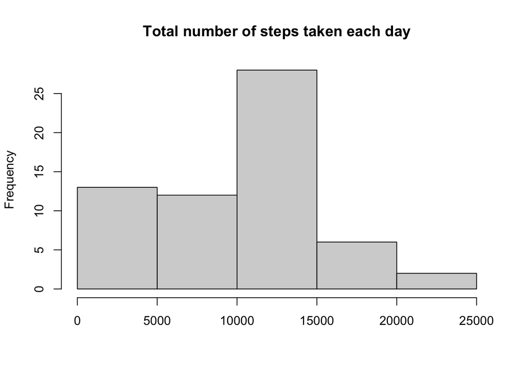

```r
stepperday <- with(data, tapply(steps, date, FUN=sum, na.rm =TRUE))
hist(stepperday, xlab= "", main="Total number of steps taken each day")
```

Let’s take a looking at the central tendency

```r
mean(stepperday)
```

```
## [1] 9354.23
```

```r
median(stepperday)
```

```
## [1] 10395
```

Let’s check again with summary function

```r
summary(stepperday)
```

```
##    Min. 1st Qu.  Median    Mean 3rd Qu.    Max.
##       0    6778   10395    9354   12811   21194
```

## Creating a time series plot

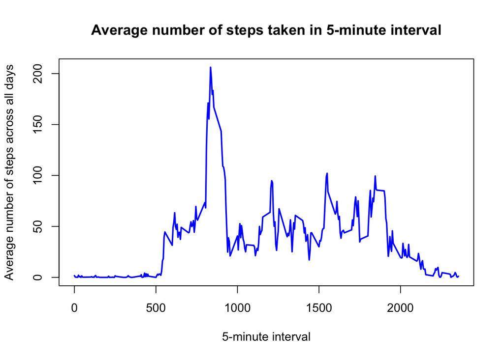

```r
stepperinterval <- aggregate(steps~interval, data=data, FUN=mean, na.rm =TRUE)
plot(stepperinterval$interval, stepperinterval$steps,
     type = "l", lwd = 2, col="blue",
     xlab= "5-minute interval",
     ylab= "Average number of steps across all days",
     main="Average number of steps taken in 5-minute interval")
```

Let’s fetch the interval with maximum number of steps

```r
stepperinterval[which.max(stepperinterval$steps),]
```

```
##     interval    steps
## 104      835 206.1698
```

## Imputing missing values

Note that there are a number of days/intervals where there are missing values (coded as NA). The presence of missing days may introduce bias into some calculations or summaries of the data.

Let’s calculate the total number of missing values in the dataset (i.e. the total number of rows with NAs).

```r
sum(is.na(data))
```

```
## [1] 2304
```

Let’s fill in all of the missing values in the dataset by using the mean for that 5-minute interval.

```r
sum(is.na(data))
```

```
## [1] 2304
```

Now, we create a new dataset that is equal to the original dataset but with the missing data filled in.

```r
data2 <- data
nulstep <- is.na(data2$steps)
avg_interval <- tapply(data2$steps, data2$interval, mean,
                       na.rm=TRUE, simplify = TRUE)
data2$steps[nulstep] <-avg_interval[as.character(data2$interval[nulstep])]

# check if there are missing data in the new dataset
sum(is.na(data2))
```

```
## [1] 0
```

Now that we have imputed missing values. We might want to know if these values differ from the estimates from the first part of the assignment, or what the impact of imputing missing data on the estimates of the total daily number of steps is. Let’s make a histogram of the total number of steps taken each day with the new and original data side by side for comparison.

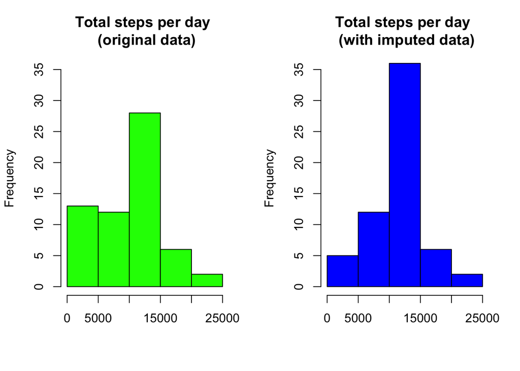

```r
par(mfrow = c(1,2))

stepperday <- with(data, tapply(steps, date, FUN=sum, na.rm =TRUE))
hist(stepperday, xlab= "", main="Total steps per day \n (original data)",
     col = "green", ylim=c(0,35))

newstepperday <- with(data2, tapply(steps, date, FUN=sum, na.rm =TRUE))
hist(newstepperday, xlab= "", main="Total steps per day \n (with imputed data)", col = "blue", ylim=c(0,35))
```

```r
summary(data)
```

```
##      steps             date               interval
##  Min.   :  0.00   Min.   :2012-10-01   Min.   :   0.0
##  1st Qu.:  0.00   1st Qu.:2012-10-16   1st Qu.: 588.8
##  Median :  0.00   Median :2012-10-31   Median :1177.5
##  Mean   : 37.38   Mean   :2012-10-31   Mean   :1177.5
##  3rd Qu.: 12.00   3rd Qu.:2012-11-15   3rd Qu.:1766.2
##  Max.   :806.00   Max.   :2012-11-30   Max.   :2355.0
##  NA's   :2304
```

```r
summary(data2)
```

```
##      steps             date               interval
##  Min.   :  0.00   Min.   :2012-10-01   Min.   :   0.0
##  1st Qu.:  0.00   1st Qu.:2012-10-16   1st Qu.: 588.8
##  Median :  0.00   Median :2012-10-31   Median :1177.5
##  Mean   : 37.38   Mean   :2012-10-31   Mean   :1177.5
##  3rd Qu.: 27.00   3rd Qu.:2012-11-15   3rd Qu.:1766.2
##  Max.   :806.00   Max.   :2012-11-30   Max.   :2355.0
```

Next, we might want to know if there are differences in activity patterns between weekdays and weekends. For this part the weekdays() function may be of some help here. Let’s use the dataset with the filled-in missing values for this part.

First, we create a new factor variable in the dataset with two levels – “weekday” and “weekend” indicating whether a given date is a weekday or weekend day.

```r
head(data2)
```

```
##       steps       date interval
## 1 1.7169811 2012-10-01        0
## 2 0.3396226 2012-10-01        5
## 3 0.1320755 2012-10-01       10
## 4 0.1509434 2012-10-01       15
## 5 0.0754717 2012-10-01       20
## 6 2.0943396 2012-10-01       25
```

```r
# Add a new variable indicating weekday and weekend
data2$dayofweek <- ifelse(weekdays(data2$date) =="Saturday"| weekdays(data2$date) =="Sunday", "Weekend", "Weekday")
# Check the new variable
head(data2)
```

```
##       steps       date interval dayofweek
## 1 1.7169811 2012-10-01        0   Weekday
## 2 0.3396226 2012-10-01        5   Weekday
## 3 0.1320755 2012-10-01       10   Weekday
## 4 0.1509434 2012-10-01       15   Weekday
## 5 0.0754717 2012-10-01       20   Weekday
## 6 2.0943396 2012-10-01       25   Weekday
```

```r
table(data2$dayofweek)
```

```
##
## Weekday Weekend
##   12960    4608
```

Then, we make a panel plot containing a time series plot (i.e. type = “l”) of the 5-minute interval (x-axis) and the average number of steps taken, averaged across all weekday days or weekend days (y-axis).

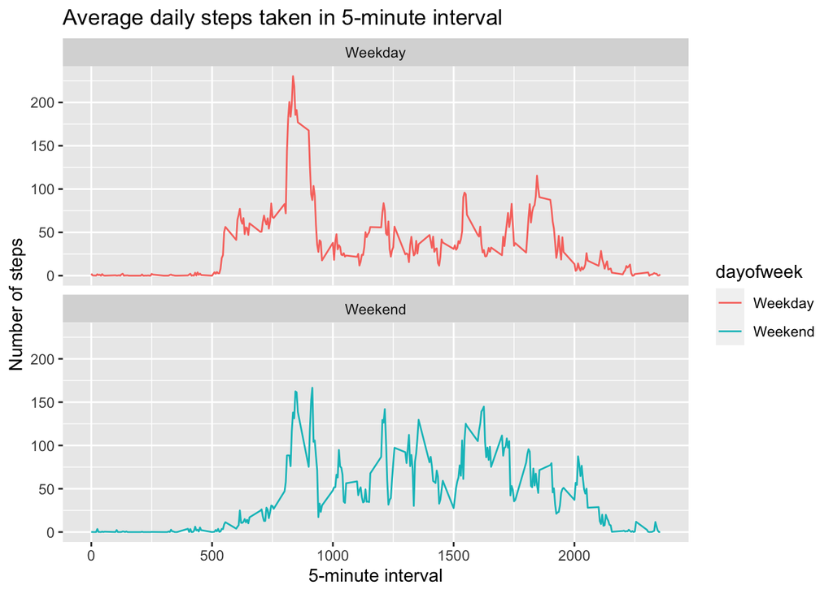

```r
stepperinterval2 <- aggregate(steps~interval + dayofweek, data=data2, FUN=mean)
# time series plot with ggplot
library(ggplot2)
ggplot(stepperinterval2, aes(x=interval, y= steps, color=dayofweek)) +
  geom_line() +
  labs(title="Average daily steps taken in 5-minute interval",
       x= "5-minute interval",
       y= "Number of steps") +
  facet_wrap(~dayofweek, ncol=1, nrow=2)
```